# Regression 1

February 10 2025

## The body data

A motivating example - The body data

```r
library(BIAS.data)
head(bodydata,10)
```

```
##    Weight Height Age Circumference
## 1    65.6  174.0  21          71.5
## 3    80.7  193.5  28          83.2
## 4    72.6  186.5  23          77.8
## 5    78.8  187.2  22          80.0
## 6    74.8  181.5  21          82.5
## 7    86.4  184.0  26          82.0
## 8    78.4  184.5  27          76.8
## 9    62.0  175.0  23          68.5
## 10   81.6  184.0  21          77.5
## 11   76.6  180.0  23          81.9
```

## Scatterplots

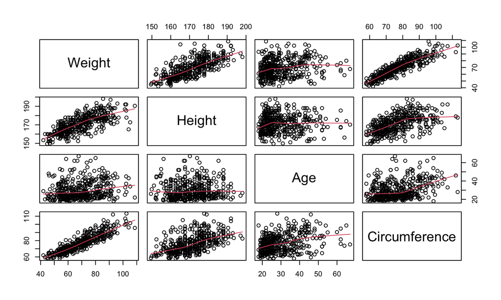

## The Weight versus Height

Is there a linear relationship between Weight and Height?

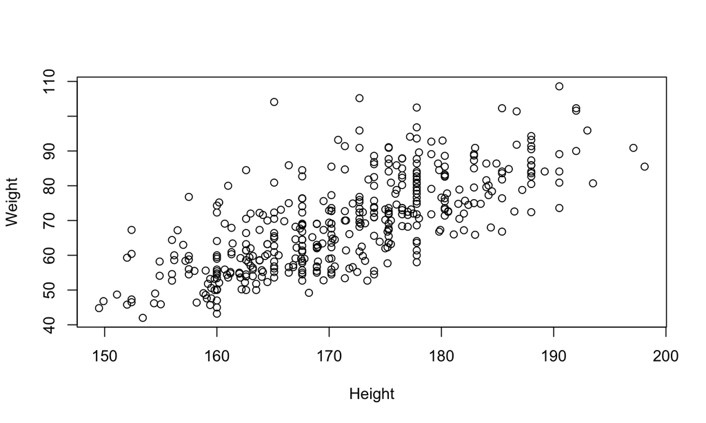

If so, what is the “best” fitting line?

## A graphical presentation of a simple linear model

Let’s use a web applet to discuss the “best” fitting line: http://solve.shinyapps.io/LeastSquaresApp

## The main idea

A continuous response variable, \(y\), is assumed to be linearly dependent on one or several predictor variables, \(x_1, x_2, \ldots, x_p\)

A simple regression model (one predictor)

\(y = \beta_0 + \beta_1 x + \epsilon, \epsilon \sim N(0, \sigma^2)\)

A multiple regression model (multiple predictors)

\(y = \beta_0 + \beta_1 x_1 + \beta_2 x_2 + \cdots+ \beta_p x_p +\epsilon, \epsilon \sim N(0, \sigma^2)\)

## Estimation of regression coefficients

Unknown regression coefficients of a simple regression model are \(\beta_0\) and \(\beta_1\)

Estimation of parameters is equivalent to finding the “best fitting” model.

Different estimation methods \(\Leftrightarrow\) Different definitions of “best”.

- Least squares estimator : The estimates minimize \(SSE(\beta_0,\beta_1) = \sum (y_i - ({\beta}_0 + {\beta}_1 x_i))^2\rightarrow\min\)
- Equivalent to the maximum likelihood estimator: The estimates make the observed data “most likely”
- \[ f(y_1,...,y_n)\rightarrow\max \]

## Maximum likelihood formulation

Recall normal pdf\(f(y) = \frac{1}{\sigma\sqrt{2\pi}} \exp\left\{-\frac{1}{2}\left(\frac{y-\mu}{\sigma}\right)^2\right\}\)

## Derivations for maxima

## Estimation of unexplained variance

As soon as we have defined the “best” fitting model, we have also defined all distances between the observations and the estimated model.

These distances are the residuals: \[d_i = y_i - (\widehat{\beta}_0 + \widehat{\beta}_1 x_i)\] for \(i=1,\ldots,n\)

An unbiased estimator for the error variance \(\sigma^2\) depends on these distances through \[ \widehat{\sigma}^2 = \sum d_i^2/(n-p-1) = \frac{SSE}{(n-p-1)} = MSE\]

where \(p\) is the number of predictors.

## Example: Regression in R (Model 1)

We use samples 1 to 20 of the bodydata as example data (training set)

\[ y_i = \beta_0 +\beta_1 x_{1i} + \epsilon_i \] where \(y\) is Weight, \(x_1\) is Height and \(i=1,\ldots, 20\).

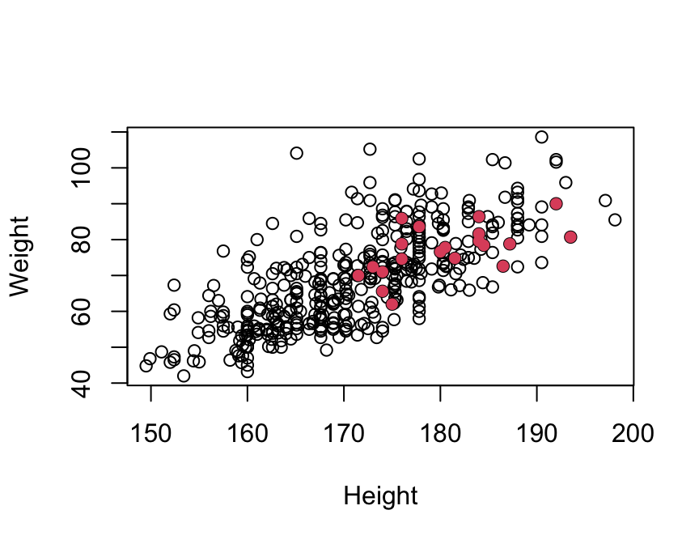

## Example of model fit in R Studio

```r
LinearModel.1 <- lm(Weight ~ Height, data=bodydata, subset=1:20)
summary(LinearModel.1)
```

## Output

```
##
## Call:
## lm(formula = Weight ~ Height, data = bodydata, subset = 1:20)
##
## Residuals:
##      Min       1Q   Median       3Q      Max
## -11.5160  -2.5964   0.0261   2.9141  11.7454
##
## Coefficients:
##             Estimate Std. Error t value Pr(>|t|)
## (Intercept) -38.2310    38.3605  -0.997  0.33216
## Height        0.6386     0.2123   3.007  0.00757 **
## ---
## Signif. codes:  0 '***' 0.001 '**' 0.01 '*' 0.05 '.' 0.1 ' ' 1
##
## Residual standard error: 5.839 on 18 degrees of freedom
## Multiple R-squared:  0.3344, Adjusted R-squared:  0.2974
## F-statistic: 9.043 on 1 and 18 DF,  p-value: 0.007566
```

## The fitted line plot

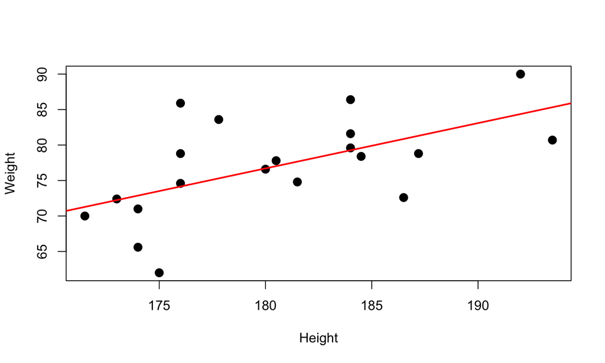

```r
plot(Weight~Height, data=bodydata, subset=1:20, pch=20, cex=2)
abline(LinearModel.1, lwd=2, col="red")
```

## Weight versus Circumference (Model 2)

Now let:

\[ y_i = \beta_0 +\beta_1 x_{2i} + \epsilon_i \]

where \(y\) still is Weight, \(x_2\) is Circumference and \(i=1,\ldots, 20\).

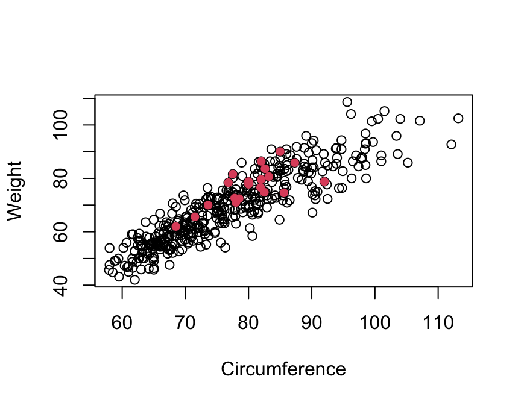

## R Commander output

```
##
## Call:
## lm(formula = Weight ~ Circumference, data = bodydata, subset = 1:20)
##
## Residuals:
##    Min     1Q Median     3Q    Max
## -8.937 -3.540  0.038  2.956  8.659
##
## Coefficients:
##               Estimate Std. Error t value Pr(>|t|)
## (Intercept)     3.6737    17.1036   0.215 0.832343
## Circumference   0.9137     0.2125   4.300 0.000431 ***
## ---
## Signif. codes:  0 '***' 0.001 '**' 0.01 '*' 0.05 '.' 0.1 ' ' 1
##
## Residual standard error: 5.027 on 18 degrees of freedom
## Multiple R-squared:  0.5067, Adjusted R-squared:  0.4793
## F-statistic: 18.49 on 1 and 18 DF,  p-value: 0.0004311
```

How can we claim that this model gives a better fit than model1?

## A measure of goodness of fit, the \(R^2\)

The unconditional (sample) variability of Weight is: \[\sum (y_i - \bar{y})^2 = {SST}\] Hence, \(SST\) (in some literature \(SSY\)) is a measure of total variability in y, the response

Further, \(SSE\) is a measure of unexplained variability in y

So, a measure of explained variability is \[R^2 = \frac{SST-SSE}{SST} = 1-\frac{SSE}{SST}\]

## Multiple linear regression (Model 3)

\[y_i = \beta_0 + \beta_1 x_{1i} + \beta_2x_{2i} + \epsilon_i\]

where \(y\) is Weight, \(x_1\) is Height \(x_2\) is Circumference and \(i=1,\ldots, 20\).

## R Studio output (Model 3)

```
##
## Call:
## lm(formula = Weight ~ Height + Circumference, data = bodydata,
##     subset = 1:20)
##
## Residuals:
##     Min      1Q  Median      3Q     Max
## -5.3189 -3.5363 -0.7817  2.8028  6.3974
##
## Coefficients:
##               Estimate Std. Error t value Pr(>|t|)
## (Intercept)   -70.8202    28.4518  -2.489 0.023464 *
## Height          0.4731     0.1566   3.021 0.007698 **
## Circumference   0.7777     0.1820   4.273 0.000515 ***
## ---
## Signif. codes:  0 '***' 0.001 '**' 0.01 '*' 0.05 '.' 0.1 ' ' 1
##
## Residual standard error: 4.172 on 17 degrees of freedom
## Multiple R-squared:  0.679,  Adjusted R-squared:  0.6413
## F-statistic: 17.98 on 2 and 17 DF,  p-value: 6.38e-05
```

## Three predictors…(Model 4)

```
##
## Call:
## lm(formula = Weight ~ Height + Circumference + Age, data = bodydata,
##     subset = 1:20)
##
## Residuals:
##     Min      1Q  Median      3Q     Max
## -5.4088 -3.3900 -0.9123  3.0403  6.9827
##
## Coefficients:
##               Estimate Std. Error t value Pr(>|t|)
## (Intercept)   -66.5785    30.0098  -2.219 0.041330 *
## Height          0.4768     0.1600   2.981 0.008831 **
## Circumference   0.7769     0.1858   4.181 0.000706 ***
## Age            -0.2094     0.3731  -0.561 0.582352
## ---
## Signif. codes:  0 '***' 0.001 '**' 0.01 '*' 0.05 '.' 0.1 ' ' 1
##
## Residual standard error: 4.259 on 16 degrees of freedom
## Multiple R-squared:  0.6852, Adjusted R-squared:  0.6262
## F-statistic: 11.61 on 3 and 16 DF,  p-value: 0.0002729
```

## \(R^2\)-adjusted

\[R^2 = 1 - \frac{SSE}{SST} \text{, but the Problem: $R^2$ always increases when adding predictors}\]

\[R^2_{\text{adj}} = 1 - \frac{\widehat\sigma^2}{\widehat{Var}(y)} = 1 - \frac{SSE/(n-p-1)}{SST/(n-1)}\] The Solution: \(R^2_{\text{adjusted}}\) penalizes adding parameters

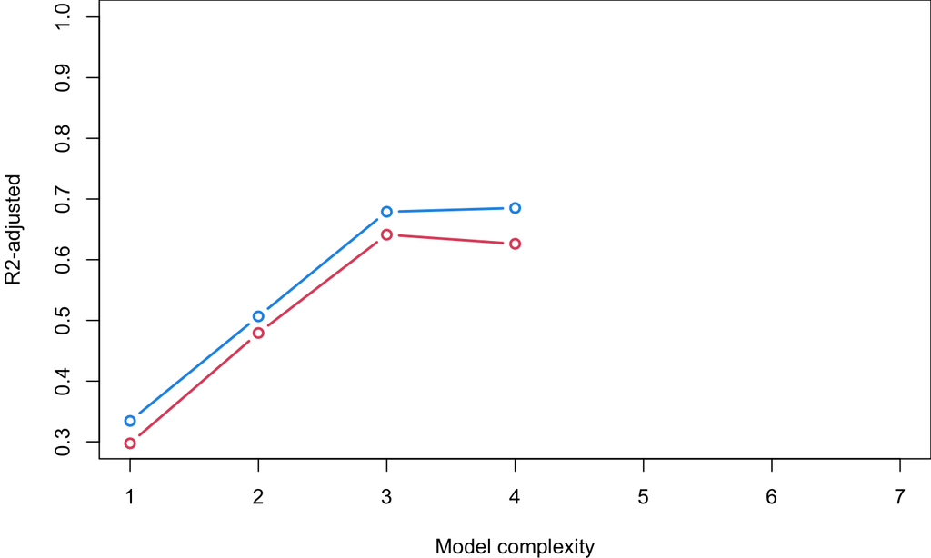

## Hypothesis Test for Regression Coefficients

We may test the **conditional significance** of any predictor using a t-test

**Hypotheses:**

- \(H_0: \beta_j = 0\) (predictor has **no effect** on response)
- \(H_1: \beta_j \neq 0\) (predictor **does have an effect**)

**Test statistic:** \[T_j = \frac{\widehat{\beta}_j-0}{SE(\widehat{\beta}_j)} \sim t_{n-p-1}\]

## Visual explanation

## Decision rule

The **p-value** is the probability of observing a test statistic as extreme or more extreme than the observed value, **assuming** \(H_0\) is true

\[\text{p-value} = P(|T| \geq |T_{\text{obs}}|) = 2 \times P(T > |T_{\text{obs}}|)\]

- **p-value is small** (e.g., 0.002): It’s **very unlikely** to observe such an extreme
- T if \(H_0\) were true → Strong evidence against \(H_0\) → **Reject** \(H_0\)

**At significance level of 0.05:**

- Reject \(H_0\) if \(|T_j| > \tau_{\alpha/2, n-p-1}\) (i.e., p-value \(< 0.05\))
- Fail to reject \(H_0\) if \(|T_j| \leq \tau_{\alpha/2, n-p-1}\) (i.e., p-value \(\geq 0.05\))

## Example: Model 4 Significance tests

```
##                  Estimate Std. Error    t value     Pr(>|t|)
## (Intercept)   -66.5785315 30.0098013 -2.2185596 0.0413297267
## Height          0.4768387  0.1599838  2.9805444 0.0088305547
## Circumference   0.7768555  0.1858173  4.1807501 0.0007063713
## Age            -0.2094104  0.3730630 -0.5613273 0.5823518801
```

**Key insight:**

- Age is not significant (p = 0.582 >> 0.05)
- Explains why adding Age slightly reduces \(R^2_{\text{adj}}\) - Model 3 (without Age) is **better choice** than Model 4
- Other predictors are significant

## Confidence interval for regression coefficients

A \((1-\alpha)\cdot 100 \%\) for \(\beta_j\) is mathematically given by: \[ \left[ \widehat{\beta}_j\pm \tau_{\alpha/2, (n-p-1)} SE(\widehat{\beta}_j) \right]\]

In RStudio we can get these (ex. for model 4) by

```r
confint(LinearModel.4, level=0.95)
```

```
##                      2.5 %     97.5 %
## (Intercept)   -130.1964683 -2.9605946
## Height           0.1376883  0.8159891
## Circumference    0.3829405  1.1707706
## Age             -1.0002686  0.5814477
```

## Prediction

A fitted model can be used for prediction of new observations

According to model 4, what is the predicted Weight of some person with these values?

```
##   Height Circumference Age
## 1    171            76  30
```

\[ \begin{split} \widehat{y} &= -66.579 + 0.4768\cdot171 + 0.7769\cdot76 - 0.2094\cdot30 \\ & = 67.72 \end{split} \]

```r
newobs <- data.frame('Height'=171, 'Circumference'=76, 'Age'=30)
predict.lm(LinearModel.4, newdata=newobs)
```

```
##       1
## 67.7196
```

## Other intervals in Prediction output

Confidence interval for \(E(y|x_1, \ldots, x_p)\)

```r
predict.lm(LinearModel.4, newdata=newobs,
           level=0.95, interval=c("confidence"))
```

```
##       fit      lwr      upr
## 1 67.7196 60.98252 74.45668
```

Prediction interval for \(y|x_1, \ldots, x_p\)

```r
predict.lm(LinearModel.4, newdata=newobs,
           level=0.95, interval=c("prediction"))
```

```
##       fit      lwr      upr
## 1 67.7196 56.45463 78.98456
```

## Compare real and predicted values

Let’s predict the 387 extra observations and compare with actual observations!

```
##         fit      lwr      upr
## 25 73.94436 64.06824 83.82047
## 26 82.80148 72.72603 92.87693
## 27 81.03059 71.44393 90.61725
## 28 71.46852 61.81893 81.11811
## 29 65.93065 55.27452 76.58677
## 31 76.31124 66.90951 85.71296
## 32 69.35871 59.61763 79.09979
## 33 75.73802 65.67258 85.80346
## 34 82.52507 72.84459 92.20555
## 35 67.71321 57.86212 77.56431
## 37 73.86325 64.29154 83.43496
## 39 74.81258 65.46899 84.15617
```

## Predicted vs observed - plot

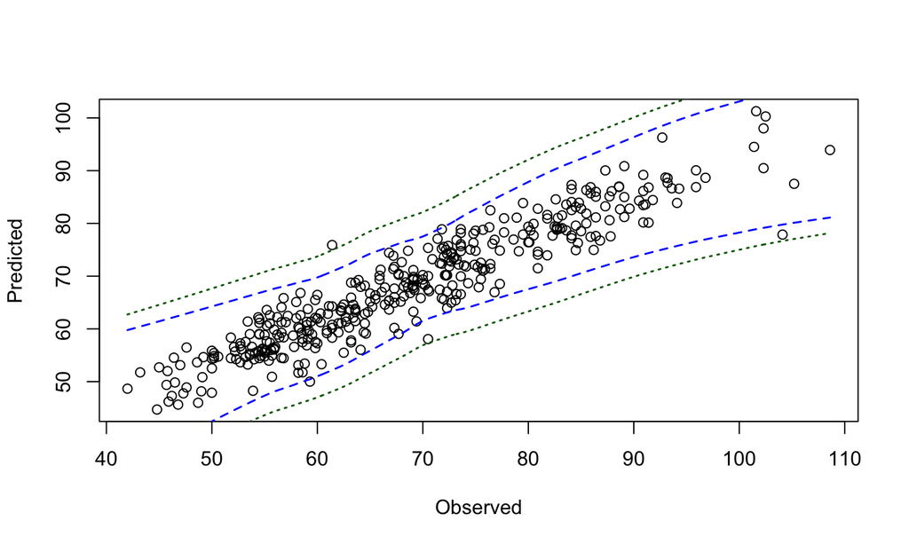

## Checking the prediction intervals

How many observations fell within the prediction intervals?

```r
largerthanlower <- (newWeight > pred[,2])
smallerthanupper <- (newWeight < pred[,3])
inInterval <- which(largerthanlower & smallerthanupper)
print(length(inInterval))
```

```
## [1] 381
```

Proportion of observations within prediction intervals:

```r
length(inInterval)/length(newWeight)
```

```
## [1] 0.9844961
```

What should we expect?